# Milestone 3

Jacob Hansen

2/28/2020

**About**

How can a political party maximize the utility of voter registration? I examine recent voter registration data in Arizona, disaggregated by county, to determine the conditions under which more voter registration best translates to more votes. Using census data, this analysis can be further disaggregated to examine the effects that race, income, and geography have on turning registrations into votes.

Using data from the Arizona Secretary of State, I joined several years’ worth of voter registration data for every Arizona county to see how the registration numbers have changed over the last four years.

Because Arizona has a large Native American population, I had to find the appropriate race variable and include it in my census analysis. Below is an example from Pima County, which featured a large percentage of the Tohono O’odham Nation.

Next steps for me will be to figure out the best way to visualize changes in voter registration data, and to determine whether or not I want to add earlier data to my analysis.

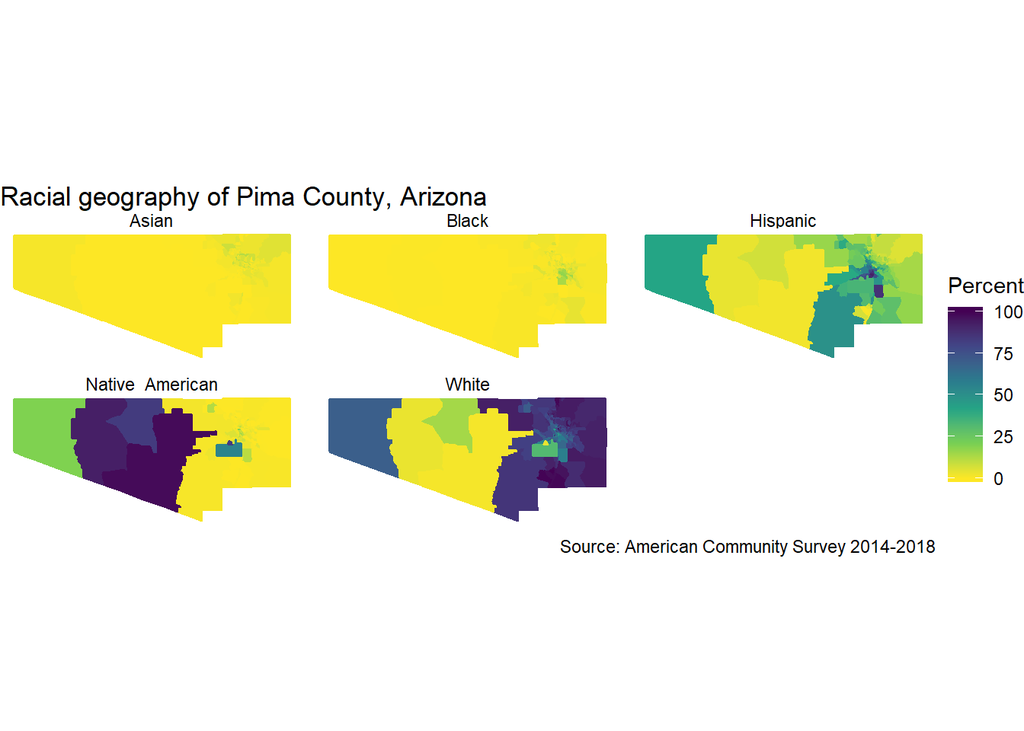